# Airline Data Analysis

Yamkela Macwili

2023-10-16

## Introduction

Delays in airline flight can be frustrating for both passengers and airlines. While some delays are caused by factors beyond anyone’s control, others can be predicted and possibly prevented. To address this issue, we aim to answer the question: “can we predict the likelihood of a flight delay?”.

Predicting flight delays is a critical task that can have a significant impact on the aviation industry. By identifying the factors that contribute to delays and developing predictive models, enhance passenger experience, and reduce the financial burden of delays on airlines.

In this analysis, we will explore historical flight data to uncover patterns and relationships that may help us predict flight delays. We will investigate various factors such as departure delays, carrier-related delays, and more.

### Load Required Libraries

```r
library("tidyverse")
library("Hmisc")
```

```r
library("corrplot")
library(knitr)
```

### Load and Inspect the Dataset

```r
# Define the file path and read the dataset
file_path <- "C:/Users/yamke/Downloads/airline_2m/airline_2m.csv"
sub_airline <- read.csv(file_path, nrows = 8000)

# Display the structure of the dataset
glimpse(sub_airline)
```

```
## Rows: 8,000
## Columns: 109
## $ Year                            <int> 1998, 2009, 2013, 2010, 2006, 1995, 20…
## $ Quarter                         <int> 1, 2, 2, 3, 1, 4, 3, 2, 3, 1, 4, 2, 3,…
## $ Month                           <int> 1, 5, 6, 8, 1, 11, 8, 6, 8, 2, 11, 4, …
## $ DayofMonth                      <int> 2, 28, 29, 31, 15, 29, 7, 11, 3, 8, 21…
## $ DayOfWeek                       <int> 5, 4, 6, 2, 7, 3, 1, 2, 7, 4, 4, 4, 7,…
## $ FlightDate                      <chr> "1998-01-02", "2009-05-28", "2013-06-2…
## $ Reporting_Airline               <chr> "NW", "FL", "MQ", "DL", "US", "DL", "C…
## $ DOT_ID_Reporting_Airline        <int> 19386, 20437, 20398, 19790, 20355, 197…
## $ IATA_CODE_Reporting_Airline     <chr> "NW", "FL", "MQ", "DL", "US", "DL", "C…
## $ Tail_Number                     <chr> "N297US", "N946AT", "N665MQ", "N6705Y"…
## $ Flight_Number_Reporting_Airline <int> 675, 671, 3297, 1806, 465, 1198, 1431,…
## $ OriginAirportID                 <int> 13487, 13342, 11921, 12892, 11618, 112…
## $ OriginAirportSeqID              <int> 1348701, 1334202, 1192102, 1289201, 11…
```

[output cut: 96 more lines]

The dataset has 8000 rows and 109 columns.

## Dataset Glossary

Now let’s look at the features and description of the dataset.

```r
url <- "C:/Users/yamke/OneDrive/Documents/Airline Analysis/Airline/table3.csv"
dataset_glossary <- read.csv(url)

# Print the dataset glossary in tabular format
kable(dataset_glossary)
```

| Feature | Description |
| --- | --- |
| Year | Year |
| Quarter | Quarter |
| Month | Month |
| DayofMonth | Day of Month |
| DayOfWeek | Day of Week (numeric) |
| FlightDate | Date of Flight |
| Reporting_Airline | Airline Unique Carrier Code |
| DOT_ID_Reporting_Airline | Number assigned by US DOT to identify a unique airline |
| IATA_CODE_Reporting_Airline | Airline Code assigned by IATA |
| Tail_Number | Aircraft tail number |
| Flight_Number_Reporting_Airline | Flight Number |
| OriginAirportID | Origin Airport ID |
| OriginAirportSeqID | Origin Airport Sequence ID |
| OriginCityMarketID | Origin City Market ID |
| Origin | Origin Airport Code |
| OriginCityName | Origin City Name |
| OriginState | Origin State |
| OriginStateFips | Origin State FIPS place code |
| OriginStateName | Origin State Name |
| OriginWac | Origin Airport World Area Code |
| DestAirportID | Destination Airport ID |
| DestAirportSeqID | Destination Airport Sequence ID |
| DestCityMarketID | Destination City Market ID |
| Dest | Destination Airport Code |
| DestCityName | Destination City Name |
| DestState | Destination State |
| DestStateFips | Destination State FIPS code |
| DestStateName | Destination State Name |
| DestWac | Destination Airport World Area Code |
| CRSDepTime | Computer Reservation System (scheduled) Departure Time |

[output cut: 79 more lines]

Variables of the Airline-Reporting Carrier On-Time Performance dataset include:

- The target value “ArrDelay” or “ArrDelayMinutes”.
- Reasons for delay.

## Data Preprocessing

Lets us have a look at the our dataset for missing values.

```r
# Count missing values in all columns
missing_values <- sub_airline %>% map(~sum(is.na(.)))
missing_values
```

[output not shown]

[output cut: 271 more lines]

[output not shown]

Dealing with the missing values first. N/A on our delay type means no delay, therefore we replace the missing values with 0.

```r
#Replace the missing values
sub_airline <- sub_airline %>%
  mutate(across(contains("Delay"), ~replace(., is.na(.), 0)))

# Select and view the delay-related columns
delay_columns <- select(sub_airline, contains("Delay"))
kable(head(delay_columns))
```

| DepDelay | DepDelayMinutes | DepartureDelayGroups | ArrDelay | ArrDelayMinutes | ArrivalDelayGroups | CarrierDelay | WeatherDelay | NASDelay | SecurityDelay | LateAircraftDelay | DivArrDelay |
| --- | --- | --- | --- | --- | --- | --- | --- | --- | --- | --- | --- |
| 19 | 19 | 1 | 23 | 23 | 1 | 0 | 0 | 0 | 0 | 0 | 0 |
| -2 | 0 | -1 | 0 | 0 | 0 | 0 | 0 | 0 | 0 | 0 | 0 |
| 14 | 14 | 0 | -3 | 0 | -1 | 0 | 0 | 0 | 0 | 0 | 0 |
| 0 | 0 | 0 | -20 | 0 | -2 | 0 | 0 | 0 | 0 | 0 | 0 |
| 51 | 51 | 3 | 32 | 32 | 2 | 0 | 0 | 0 | 0 | 32 | 0 |
| 0 | 0 | 0 | 11 | 11 | 0 | 0 | 0 | 0 | 0 | 0 | 0 |

Everything seems good, all the missing values are replaced with 0. Now we can visualize the data.

## Data Visualization

Histogram of ArrDelay

```r
# Check the range
range(sub_airline$ArrDelay)
```

```
## [1] -60 954
```

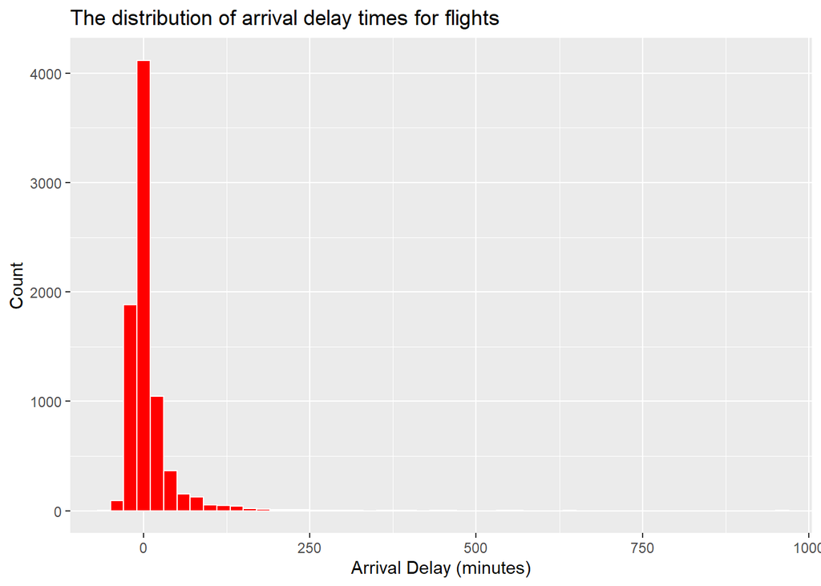

```r
# Create a histogram of ArrDelay
ggplot(data = sub_airline, mapping = aes(x = ArrDelay)) +
  geom_histogram(binwidth = 20, color = "white", fill = "red") +
  coord_cartesian(xlim = c(-60, 954))+
  labs(title = "The distribution of arrival delay times for flights",
       x = "Arrival Delay (minutes)", y = "Count")
```

### What causes a flight delay?

```r
count_airline <- sub_airline%>%
  count(sub_airline$Reporting_Airline)
kable(count_airline)
```

| sub_airline$Reporting_Airline | n |
| --- | --- |
| 9E | 83 |
| AA | 942 |
| AS | 178 |
| B6 | 118 |
| CO | 330 |
| DH | 26 |
| DL | 1079 |
| EA | 30 |
| EV | 274 |
| F9 | 60 |
| FL | 99 |
| G4 | 5 |
| HA | 38 |
| HP | 157 |
| KH | 4 |
| ML (1) | 3 |
| MQ | 330 |
| NK | 40 |
| NW | 432 |
| OH | 90 |
| OO | 461 |
| PA (1) | 14 |
| PI | 45 |
| PS | 3 |
| TW | 147 |
| TZ | 15 |
| UA | 758 |
| US | 723 |
| VX | 16 |
| WN | 1239 |
| XE | 131 |
| YV | 99 |
| YX | 31 |

```r
# Descriptive Statistics - Mean and Standard Deviation of ArrDelayMinutes
summary_airline_delay <- sub_airline %>%
  group_by(Reporting_Airline) %>%
  summarise(mean = mean(ArrDelayMinutes), std_dev = sd(ArrDelayMinutes))
kable(summary_airline_delay)
```

| Reporting_Airline | mean | std_dev |
| --- | --- | --- |
| 9E | 15.578313 | 37.349085 |
| AA | 11.145435 | 27.128910 |
| AS | 11.247191 | 28.045476 |
| B6 | 11.262712 | 27.922796 |
| CO | 12.866667 | 31.748161 |
| DH | 10.461538 | 21.628187 |
| DL | 10.142725 | 27.598164 |
| EA | 10.933333 | 18.754187 |
| EV | 13.645985 | 49.372423 |
| F9 | 28.733333 | 85.276195 |
| FL | 11.050505 | 24.889705 |
| G4 | 6.800000 | 7.563068 |
| HA | 3.947368 | 7.986297 |
| HP | 13.057325 | 44.700032 |
| KH | 12.250000 | 21.203380 |
| ML (1) | 3.666667 | 6.350853 |
| MQ | 11.215151 | 25.902185 |
| NK | 14.925000 | 29.452602 |
| NW | 9.104167 | 21.059650 |
| OH | 18.166667 | 43.053207 |
| OO | 15.477223 | 60.050758 |
| PA (1) | 5.928571 | 11.605465 |
| PI | 11.200000 | 15.862477 |
| PS | 7.333333 | 12.701706 |
| TW | 12.231293 | 30.210691 |
| TZ | 7.733333 | 25.038447 |
| UA | 16.875989 | 42.584539 |
| US | 10.201936 | 23.761118 |
| VX | 23.562500 | 74.635978 |
| WN | 10.263922 | 24.938320 |
| XE | 11.847328 | 32.571454 |
| YV | 13.373737 | 39.244806 |
| YX | 23.774193 | 100.237621 |

```r
# Create a simple average across Reporting_Airline and DayOfWeek
average_delays <- sub_airline %>%
  group_by(Reporting_Airline, DayOfWeek)%>%
  summarise(mean_delays = mean(ArrDelayMinutes))
kable(head(average_delays))
```

| Reporting_Airline | DayOfWeek | mean_delays |
| --- | --- | --- |
| 9E | 1 | 8.473684 |
| 9E | 2 | 29.545455 |
| 9E | 3 | 18.619048 |
| 9E | 4 | 4.333333 |
| 9E | 5 | 18.933333 |
| 9E | 6 | 3.857143 |

```r
#Sort the dataframe
arrange_avg_delay <- average_delays %>%
  arrange(desc(mean_delays))
kable(head(arrange_avg_delay))
```

| Reporting_Airline | DayOfWeek | mean_delays |
| --- | --- | --- |
| YX | 5 | 187.33333 |
| VX | 4 | 150.50000 |
| F9 | 1 | 74.63636 |
| OH | 4 | 46.63636 |
| KH | 1 | 44.00000 |
| OO | 5 | 39.97015 |

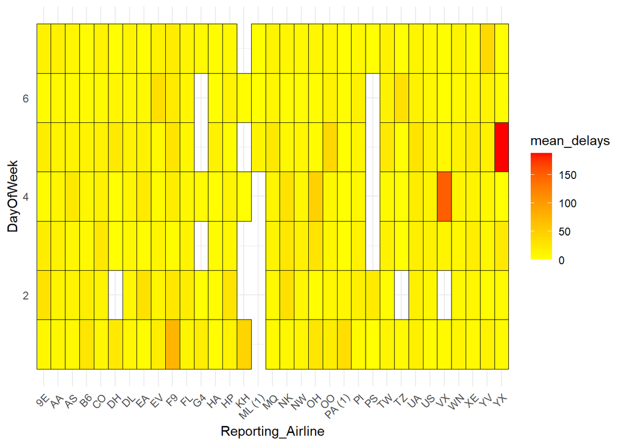

```r
# Visualize the data using Heatmap
average_delays %>%
  ggplot(aes( x = Reporting_Airline,
              y = DayOfWeek,
              fill = mean_delays))+
  geom_tile(color = "black", linewidth = 0.2)+
  scale_fill_gradient(low = "yellow",
                      high = "red")+
  theme_minimal()+
  theme(axis.text.x = element_text(angle = 45, hjust = 1))
```

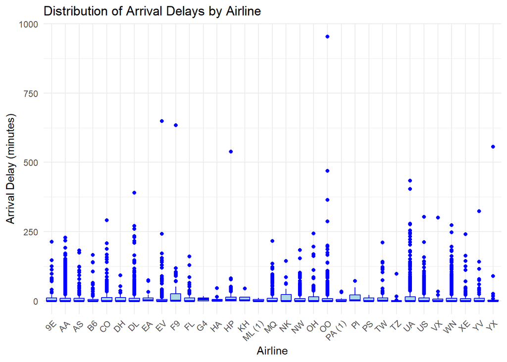

```r
ggplot(data = sub_airline, mapping = aes(x = Reporting_Airline, y = ArrDelayMinutes))+
  geom_boxplot(fill = "lightblue", color = "blue")+
  labs(title = "Distribution of Arrival Delays by Airline",
       x = "Airline", y = "Arrival Delay (minutes)")+
  theme_minimal()+
  theme(axis.text.x = element_text(angle = 45, hjust =1))
```

### Correlation Matrix Heatmap

```r
# Correlation between different delay types and ArrDelayMinutes
corr_airline <- sub_airline %>%
  select(ArrDelayMinutes, DepDelayMinutes, CarrierDelay, WeatherDelay, NASDelay, SecurityDelay, LateAircraftDelay)

airline_correlation <- rcorr(as.matrix(corr_airline), type = "pearson")
correlation_matrix <- airline_correlation$r
kable(correlation_matrix, format = "markdown")
```

|  | ArrDelayMinutes | DepDelayMinutes | CarrierDelay | WeatherDelay | NASDelay | SecurityDelay | LateAircraftDelay |
| --- | --- | --- | --- | --- | --- | --- | --- |
| ArrDelayMinutes | 1.0000000 | 0.9510640 | 0.6266076 | 0.1293258 | 0.3583874 | 0.0289321 | 0.5169887 |
| DepDelayMinutes | 0.9510640 | 1.0000000 | 0.6484311 | 0.1291708 | 0.2634974 | 0.0315422 | 0.5303645 |
| CarrierDelay | 0.6266076 | 0.6484311 | 1.0000000 | -0.0053310 | 0.0180580 | -0.0020372 | 0.0888572 |
| WeatherDelay | 0.1293258 | 0.1291708 | -0.0053310 | 1.0000000 | 0.0224852 | -0.0010936 | 0.0149123 |
| NASDelay | 0.3583874 | 0.2634974 | 0.0180580 | 0.0224852 | 1.0000000 | -0.0028939 | 0.0731567 |
| SecurityDelay | 0.0289321 | 0.0315422 | -0.0020372 | -0.0010936 | -0.0028939 | 1.0000000 | 0.0013452 |
| LateAircraftDelay | 0.5169887 | 0.5303645 | 0.0888572 | 0.0149123 | 0.0731567 | 0.0013452 | 1.0000000 |

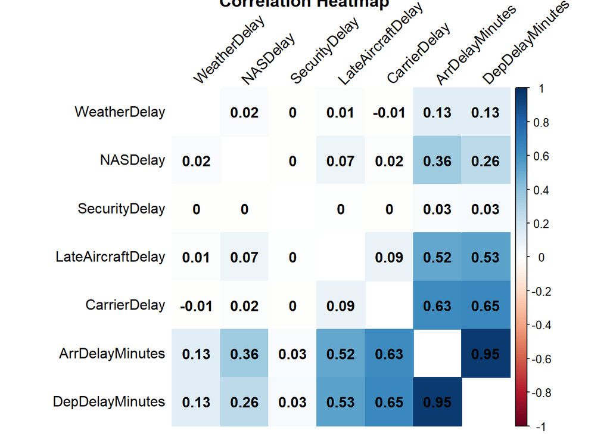

```r
corrplot(correlation_matrix, method = "color", tl.col = "black", tl.srt = 45, addCoef.col = "black", type = "full",diag = FALSE,
          title = "Correlation Heatmap", order = "hclust")
```

## Model development

### Can we predict the arrival delay of a flight?

```r
mult_linear_reg <- lm(ArrDelay ~ DepDelayMinutes + CarrierDelay + WeatherDelay + NASDelay + SecurityDelay + LateAircraftDelay, data = sub_airline)
summary(mult_linear_reg)
```

```
##
## Call:
## lm(formula = ArrDelay ~ DepDelayMinutes + CarrierDelay + WeatherDelay +
##     NASDelay + SecurityDelay + LateAircraftDelay, data = sub_airline)
##
## Residuals:
##      Min       1Q   Median       3Q      Max
## -162.674   -6.923   -0.391    6.313  253.618
##
## Coefficients:
##                    Estimate Std. Error t value Pr(>|t|)
## (Intercept)       -4.522694   0.154887 -29.200  < 2e-16 ***
## DepDelayMinutes    0.913642   0.007986 114.402  < 2e-16 ***
## CarrierDelay       0.086193   0.010719   8.041 1.02e-15 ***
## WeatherDelay       0.140914   0.034342   4.103 4.11e-05 ***
## NASDelay           0.414829   0.013742  30.187  < 2e-16 ***
## SecurityDelay      0.123307   0.125513   0.982    0.326
## LateAircraftDelay  0.106597   0.012083   8.822  < 2e-16 ***
## ---
## Signif. codes:  0 '***' 0.001 '**' 0.01 '*' 0.05 '.' 0.1 ' ' 1
##
## Residual standard error: 13.03 on 7993 degrees of freedom
## Multiple R-squared:  0.8756, Adjusted R-squared:  0.8755
## F-statistic:  9379 on 6 and 7993 DF,  p-value: < 2.2e-16
```

We can explain about 87.56% of the arrival delay of a flight with the selected delay features.

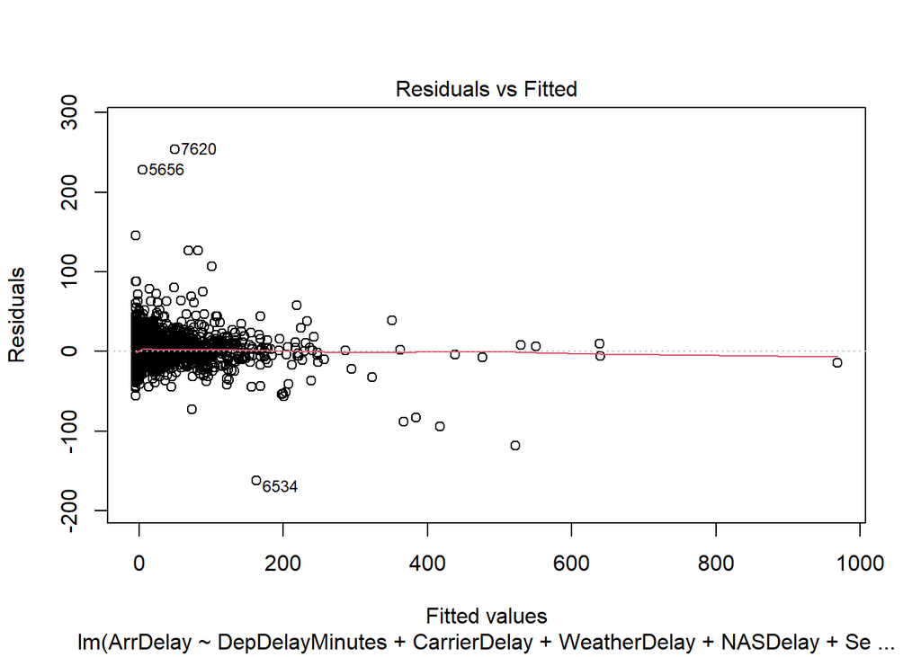

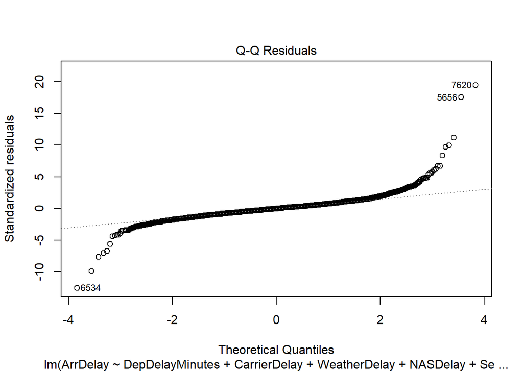

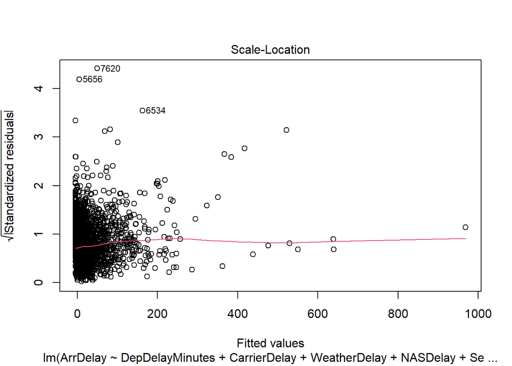

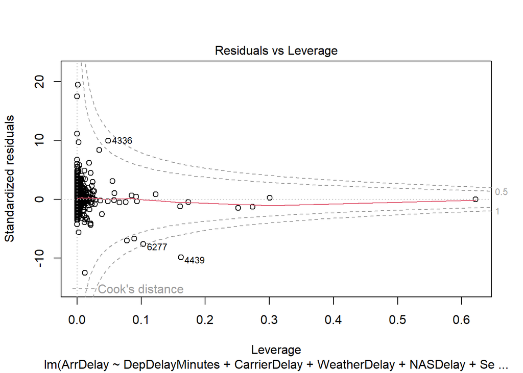

```r
plot(mult_linear_reg)
```